# CollegeScoreExplore

Keith Hultman

September 20, 2015

Explore the College Score Card Data Set

```r
getwd()
```

```
## [1] "/Volumes/Win_media/Keith_Data/CollegeScoreCard"
```

```r
setwd("./CollegeScorecard_Raw_Data/")
Scorecard2013 <- read.csv("MERGED2013_PP.csv")

summary(Scorecard2013)
```

[output not shown]

[output cut: 4969 more lines]

[output not shown]

This is a ton of extraneous data! 1729 variables - many of which are NULL throughout. These are the columns I have found that are interesting

These data I would like to graph

- COSTT4_A Cost for academic year institutions
- COSTT4_P Cost for program year institutions
- ADM_RATE Admission rate
- ACTCMMID Midpoint of ACT scores
- SATVRMID Midpoint of SAT reading
- SATMTMID Midpoint of SAT Math
- SATWRMID Midpoint of SAT Writing
- SAT_AVG Average SAT of student admitted
- UG Enrollment of undergrad
- AVGFACSAL Faculty salary
- PFTFAC proportion of faculty fulltime
- C150_4 ￼Completion rate for first-time, full-time students at four year inst.
- C150_L4 ￼Completion rate for first-time, full-time students at less than four year inst.
- RET_FT4 First-time, full-time student retention rate at four-year institutions
- RET_FTL4 First-time, full-time student retention rate at less-than-four-year institutions
- DEATH_YR2_RT Percent died within 2 years at original institution
- WDRAW_ORIG_YR2_RT Percent withdrawn from original institution within 2 years
- FIRSTGEN_COMP_ORIG_YR2_RT Percent of first-generation students who completed within 2 years at original institution
- NOT1STGEN_COMP_ORIG_YR2_RT Percent of not-first-generation students who completed within 2 years at original institution
- DEATH_YR4_RT Percent died within 4 years at original institution
- COMP_ORIG_YR4_RT Percent completed within 4 years at original institution
- COMPL_RPY_1YR_RT One-year repayment rate for completers
- NONCOM_RPY_1YR_RT One-year repayment rate for non-completers
- COMPL_RPY_3YR_RT Three-year repayment rate for completers
- NONCOM_RPY_3YR_RT Three-year repayment rate for non-completers
- COMPL_RPY_5YR_RT Five-year repayment rate for completers
- NONCOM_RPY_5YR_RT Five-year repayment rate for non-completers
- COMPL_RPY_7YR_RT Seven-year repayment rate for completers
- NONCOM_RPY_7YR_RT Seven-year repayment rate for non-completers
- GRAD_DEBT_MDN The median debt for students who have completed
- WDRAW_DEBT_MDN The median debt for students who have not completed

These data might be useful to filter on

- CURROPER Flag for currently operating

```r
Scorecard2013$COSTT4_A <- as.numeric(Scorecard2013$COSTT4_A)
mean(Scorecard2013$COSTT4_A, na.rm=TRUE)
```

```
## [1] 2785.84
```

```r
summary(Scorecard2013$COSTT4_A)
```

```
##    Min. 1st Qu.  Median    Mean 3rd Qu.    Max.
##       1    1788    3582    2786    3804    3804
```

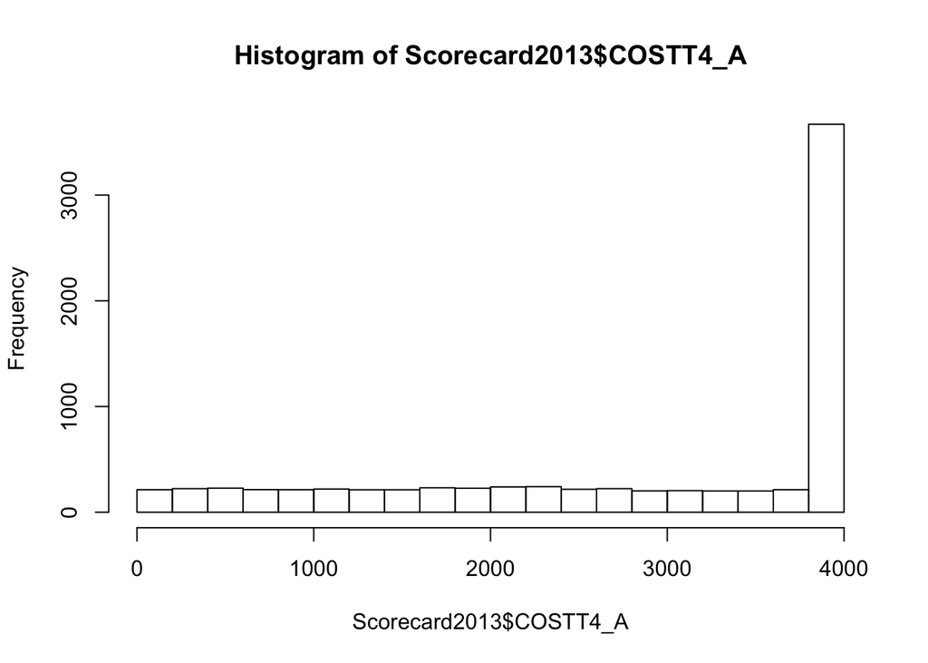

```r
hist(Scorecard2013$COSTT4_A)
```

```r
str(Scorecard2013$COSTT4_P)
```

```
##  Factor w/ 2350 levels "10027","10039",..: 2350 2350 2350 2350 2350 2350 2350 2350 2350 2350 ...
```

```r
summary(Scorecard2013$SAT_AVG)
```

```
##    NULL    1030    1070    1050    1010     950     990    1090     970
##    6384      33      27      26      24      19      18      16      16
##     930    1105    1020    1029    1053    1110     940    1028    1049
##      15      13       9       9       9       9       9       8       8
##    1087    1145     910     954    1006    1009    1014    1017    1033
##       8       8       8       8       7       7       7       7       7
##    1035    1047    1100    1102     993     995    1002    1007    1008
##       7       7       7       7       7       7       6       6       6
##    1015    1021    1024    1026    1045    1060    1069    1094    1109
##       6       6       6       6       6       6       6       6       6
##    1165     964     967     980     982     986     998    1004    1011
##       6       6       6       6       6       6       6       5       5
##    1016    1038    1046    1057    1062    1064    1068    1075    1077
##       5       5       5       5       5       5       5       5       5
##    1079    1081    1085    1098    1106    1121    1123    1125    1142
##       5       5       5       5       5       5       5       5       5
##    1158    1168    1175    1195    1240     863     937     939     957
##       5       5       5       5       5       5       5       5       5
##     965     973     974     975     976     984     989    1001    1005
##       5       5       5       5       5       5       5       4       4
##    1018    1027    1032    1034    1036    1039    1040    1048    1054
##       4       4       4       4       4       4       4       4       4
## (Other)
##     705
```

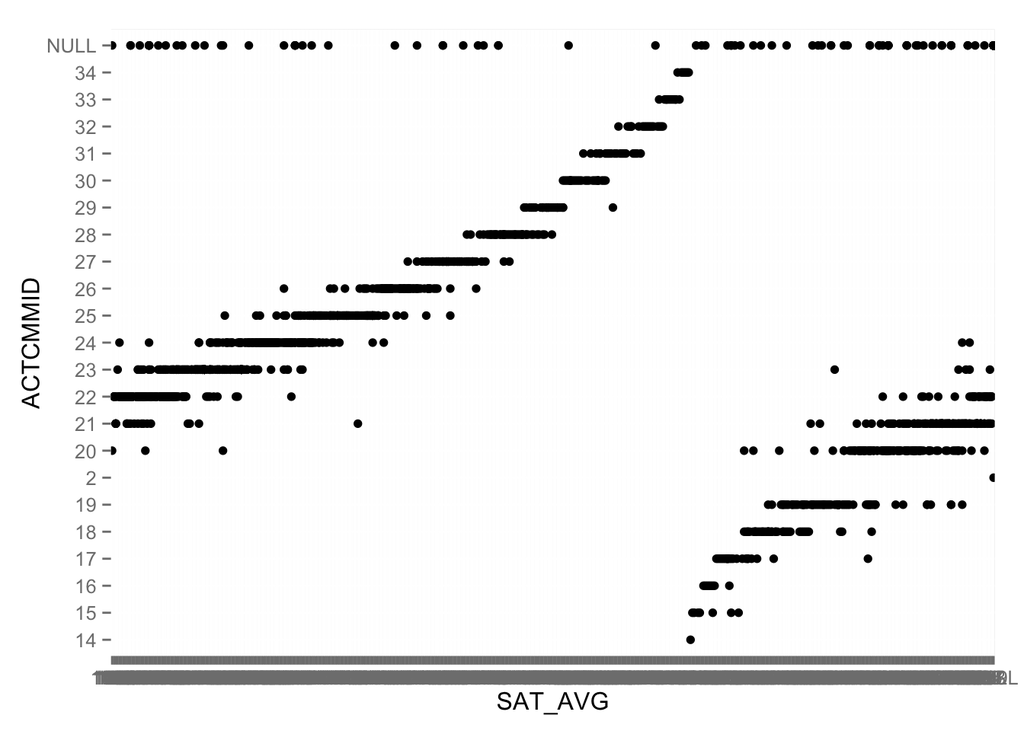

```r
library(ggplot2)

plot <- ggplot(Scorecard2013, aes(SAT_AVG, ACTCMMID))

plot + geom_point()
```

```r
str(Scorecard2013$SAT_AVG)
```

```
##  Factor w/ 478 levels "1000","1001",..: 333 143 478 170 336 162 478 478 450 196 ...
```

```r
str(Scorecard2013$ACTCMMID)
```

```
##  Factor w/ 23 levels "14","15","16",..: 4 13 23 14 4 14 23 23 9 15 ...
```

```r
newSAT_AVG <- as.numeric(levels(Scorecard2013$SAT_AVG))[Scorecard2013$SAT_AVG]
newACTCMMID <- as.numeric(levels(Scorecard2013$ACTCMMID))[Scorecard2013$ACTCMMID]
table(newSAT_AVG)
```

```
## newSAT_AVG
##  666  716  723  735  749  750  755  756  760  775  777  778  780  789  802
##    1    1    1    1    1    1    1    1    2    1    1    1    2    1    1
##  807  808  811  812  823  825  826  830  832  835  836  837  838  840  841
##    1    1    1    1    1    4    2    4    1    1    1    1    1    1    2
##  842  845  847  849  850  851  853  854  855  859  860  861  863  864  865
##    2    4    1    1    3    3    2    1    2    2    1    1    5    1    4
##  868  871  873  874  877  878  879  880  882  883  884  885  886  887  888
##    1    2    1    1    1    4    2    3    2    1    2    1    1    1    1
##  889  890  891  892  893  894  895  896  897  898  899  900  901  902  903
##    2    4    2    2    1    2    4    2    1    2    2    2    2    1    1
##  904  905  907  908  909  910  912  913  915  916  917  918  919  920  921
##    1    3    1    2    1    8    1    2    4    1    2    2    1    2    2
##  922  923  924  925  926  927  928  930  931  932  933  934  935  936  937
##    1    3    3    1    4    3    4   15    3    4    2    2    2    2    5
```

[output cut: 50 more lines]

```r
table(Scorecard2013$SAT_AVG)
```

```
##
## 1000 1001 1002 1003 1004 1005 1006 1007 1008 1009 1010 1011 1012 1013 1014
##    2    4    6    2    5    4    7    6    6    7   24    5    1    3    7
## 1015 1016 1017 1018 1019 1020 1021 1022 1023 1024 1025 1026 1027 1028 1029
##    6    5    7    4    3    9    6    2    2    6    2    6    4    8    9
## 1030 1031 1032 1033 1034 1035 1036 1037 1038 1039 1040 1041 1042 1043 1044
##   33    3    4    7    4    7    4    1    5    4    4    3    1    3    1
## 1045 1046 1047 1048 1049 1050 1051 1052 1053 1054 1055 1056 1057 1058 1059
##    6    5    7    4    8   26    2    1    9    4    1    2    5    4    1
## 1060 1061 1062 1063 1064 1065 1066 1067 1068 1069 1070 1071 1072 1073 1075
##    6    4    5    1    5    3    2    3    5    6   27    2    3    4    5
## 1076 1077 1078 1079 1080 1081 1082 1083 1084 1085 1086 1087 1088 1089 1090
##    1    5    4    5    3    5    3    3    4    5    2    8    3    3   16
## 1091 1092 1093 1094 1095 1096 1097 1098 1099 1100 1101 1102 1104 1105 1106
##    2    1    1    6    4    4    2    5    1    7    1    7    4   13    5
```

[output cut: 50 more lines]

```r
tempScore <- data.frame(newSAT_AVG, newACTCMMID)
plot <- ggplot(tempScore, aes(newSAT_AVG, newACTCMMID))
```